# examples_day03

For each of the patterns below, determine the Frieze group.

## Pattern 1

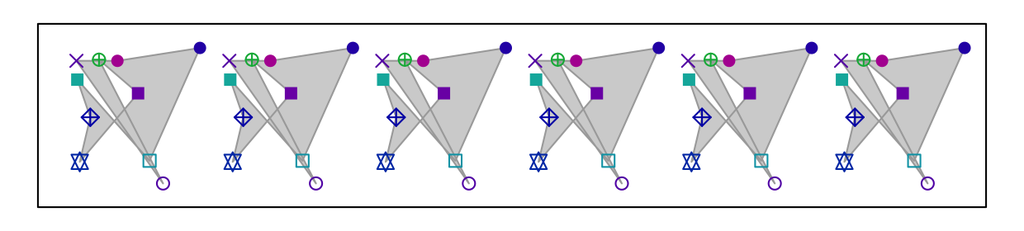

Match the IUC name:

## Pattern 2

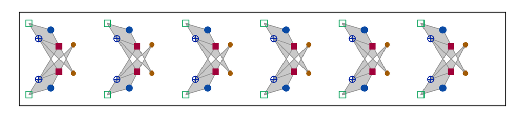

Match the Conway nickname:

- The first pattern is a p1 (which is also called hop).
- The second pattern is a jump (which is also called p11m).

For each of the patterns below, determine the Frieze group.

## Pattern 1

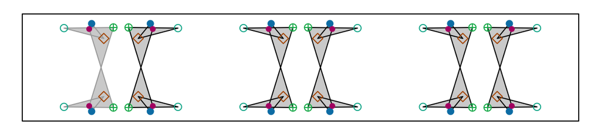

Match the IUC name:

## Pattern 2

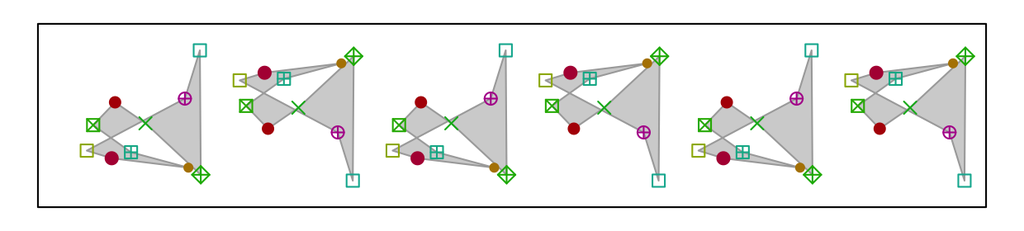

Match the Conway nickname:

- The first pattern is a p2mm (which is also called spinning jump).
- The second pattern is a step (which is also called p11g).

For each of the patterns below, determine the Frieze group.

## Pattern 1

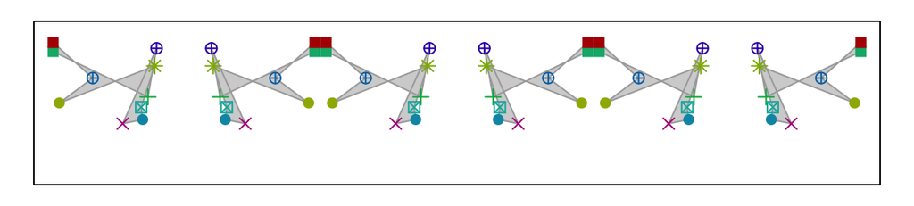

Match the IUC name:

## Pattern 2

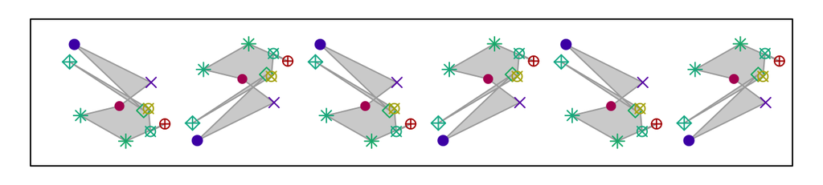

Match the Conway nickname:

- The first pattern is a p1m1 (which is also called sidle).
- The second pattern is a step (which is also called p11g).

For each of the patterns below, determine the Frieze group.

## Pattern 1

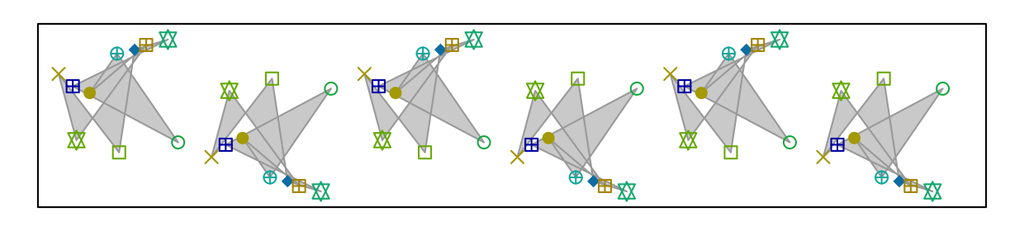

Match the IUC name:

## Pattern 2

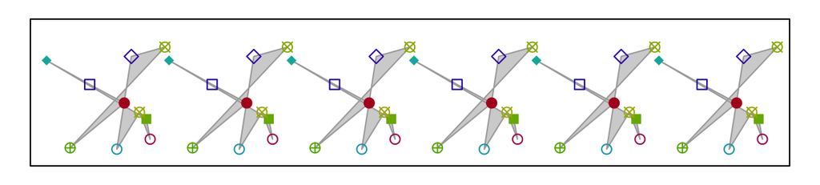

Match the Conway nickname:

- The first pattern is a p11g (which is also called step).
- The second pattern is a hop (which is also called p1).

For each of the patterns below, determine the Frieze group.

## Pattern 1

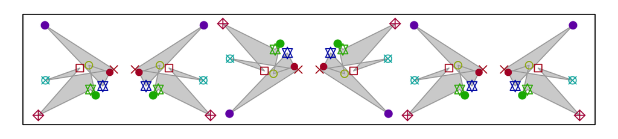

Match the IUC name:

## Pattern 2

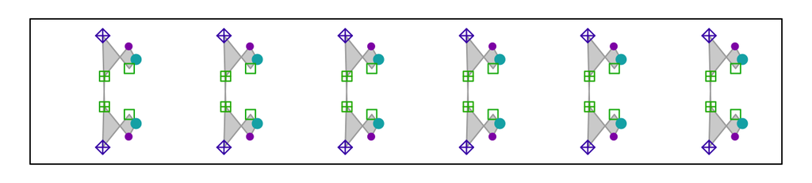

Match the Conway nickname:

- The first pattern is a p2mg (which is also called spinning sidle).
- The second pattern is a jump (which is also called p11m).

For each of the patterns below, determine the Frieze group.

## Pattern 1

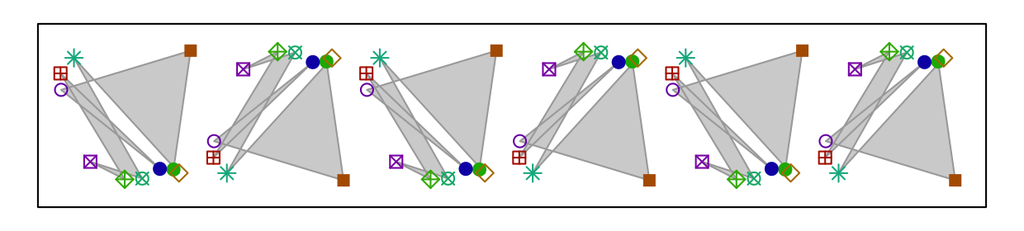

Match the IUC name:

## Pattern 2

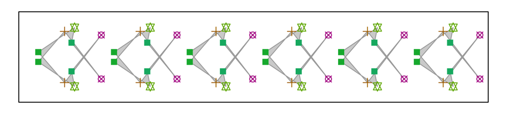

Match the Conway nickname:

- The first pattern is a p11g (which is also called step).
- The second pattern is a jump (which is also called p11m).

For each of the patterns below, determine the Frieze group.

## Pattern 1

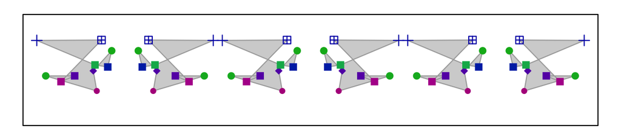

Match the IUC name:

## Pattern 2

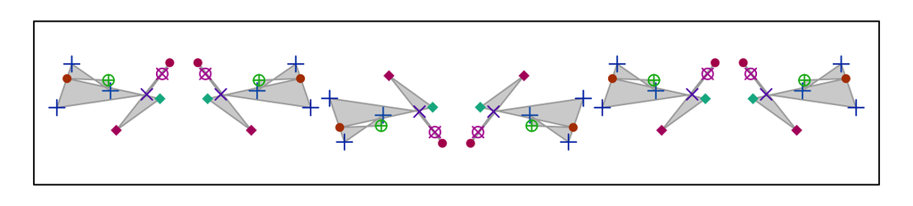

Match the Conway nickname:

- The first pattern is a p1m1 (which is also called sidle).
- The second pattern is a spinning sidle (which is also called p2mg).

For each of the patterns below, determine the Frieze group.

## Pattern 1

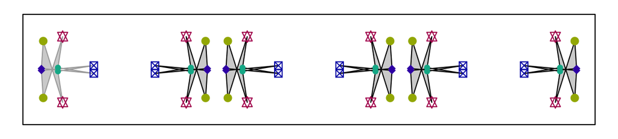

Match the IUC name:

## Pattern 2

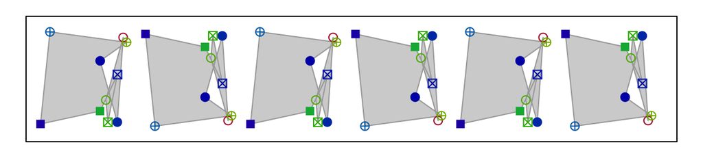

Match the Conway nickname:

- The first pattern is a p2mm (which is also called spinning jump).
- The second pattern is a step (which is also called p11g).

For each of the patterns below, determine the Frieze group.

## Pattern 1

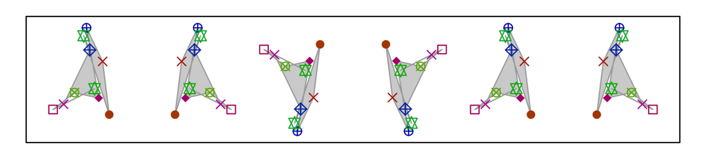

Match the IUC name:

## Pattern 2

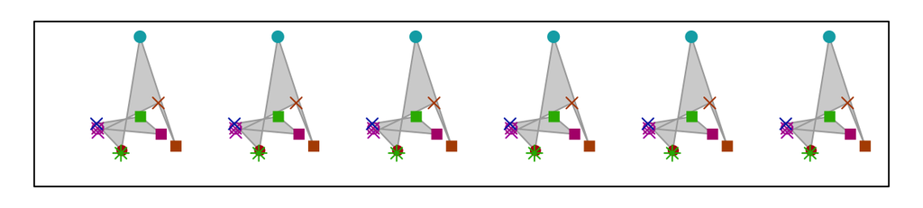

Match the Conway nickname:

- The first pattern is a p2mg (which is also called spinning sidle).
- The second pattern is a hop (which is also called p1).

For each of the patterns below, determine the Frieze group.

## Pattern 1

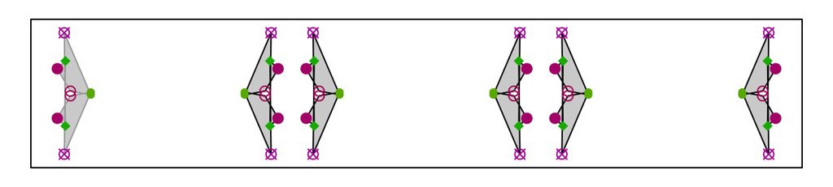

Match the IUC name:

## Pattern 2

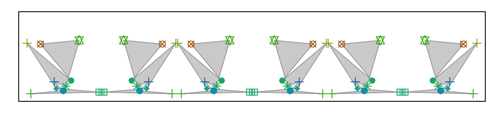

Match the Conway nickname:

- The first pattern is a p2mm (which is also called spinning jump).
- The second pattern is a sidle (which is also called p1m1).